# An In-Depth Exploration of Advanced Data Visualization Techniques with R - Penguins DEMO

## Changing legend names

You can change name that appears in your legend (not just the legend title but the contents of your legend). Here were are still using the `scale_` function and within it we are value the `labels` call to change the content of our legend. Just make sure that if you are using both `scale_fill_` and `scale_color`, you need to change the `labels` to match exactly!.

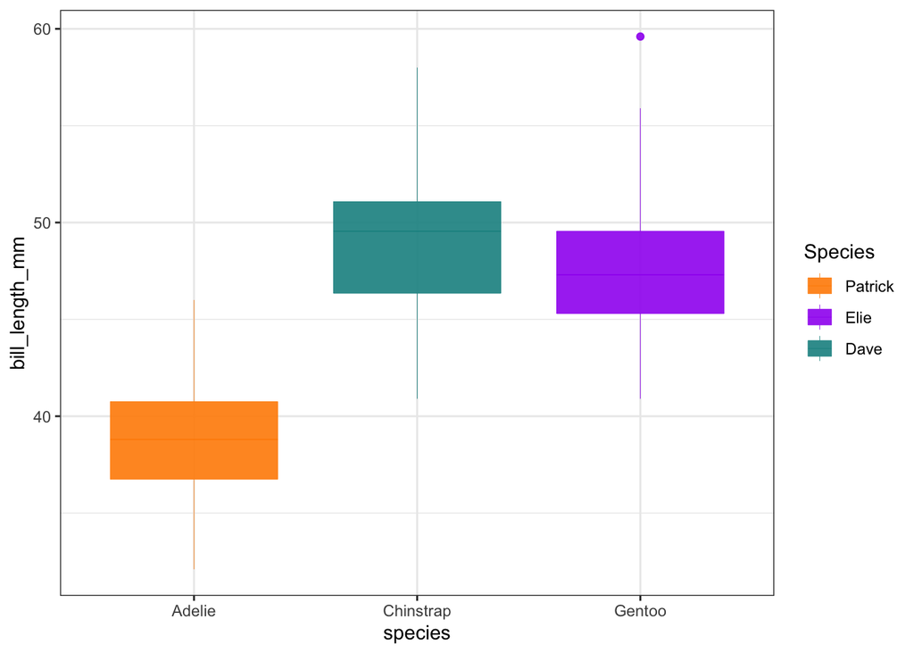

```r
penguins %>%
    ggplot(aes(x = species, y = bill_length_mm)) +
    geom_boxplot(mapping = aes(fill = forcats::fct_infreq(species),
                               color = forcats::fct_infreq(species)),
                 alpha = .9,
                 size = .15) +
    scale_fill_manual(values = pal,
                      labels = c("Patrick",
                                 "Elie",
                                 "Dave")) +
    scale_color_manual(values = pal,
                      labels = c("Patrick",
                                 "Elie",
                                 "Dave")) +
    labs(fill = "Species",
         color = "Species") +
    theme_bw()
```

**Note** you can do this change of legend even with R palettes like `scale_color_brewer` and `scale_fill_brewer`. Again all you need is the `labels` call within this function call. An example code is provided below.

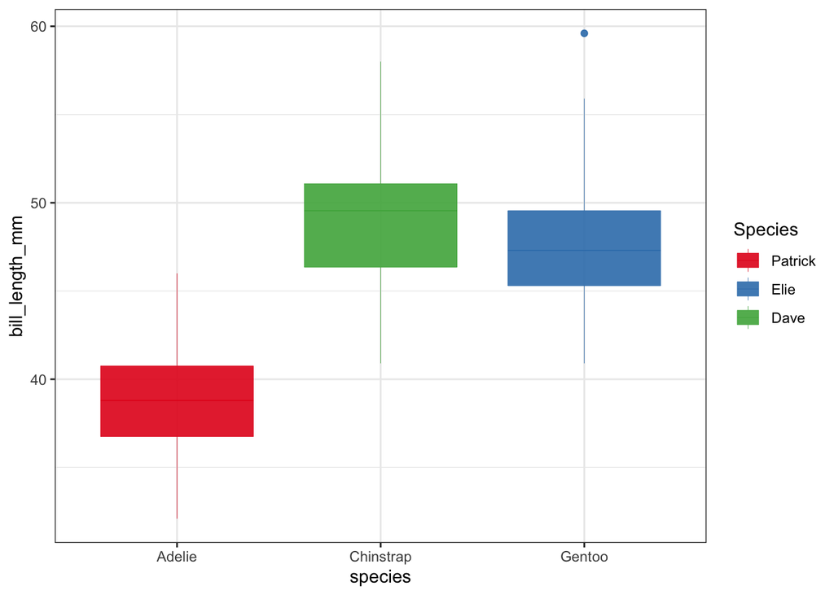

[output not shown]

[figure not shown]

```r
penguins %>%
    ggplot(aes(x = species, y = bill_length_mm)) +
    geom_boxplot(mapping = aes(fill = forcats::fct_infreq(species),
                               color = forcats::fct_infreq(species)),
                 alpha = .9,
                 size = .15) +
    scale_fill_brewer(palette = "Set1",
                      labels = c("Patrick",
                                 "Elie",
                                 "Dave")) +
    scale_color_brewer(palette = "Set1",
                      labels = c("Patrick",
                                 "Elie",
                                 "Dave")) +
    labs(fill = "Species",
         color = "Species") +
    theme_bw()
```

**Author’s Note**: I hope this document has been helpful in learning some advance elements of ggplot! Please let me know if you have any questions or feedback at ane48@pitt.edu.